# Forecasting Typhoons by Machine Learning

- Let's forecast typhoon's future like movement, wind speed, pressure, etc.

```python
import numpy as np
import pandas as pd
import matplotlib.pyplot as plt
```

# Data Load & Preprocessing

- We've already analized data on [my previous notebook](https://www.kaggle.com/code/skyil7/time-series-typhoon-eda-visualization-on-map).
- So Let's jump right into fun parts.

```python
# code nó chia theo từng dòng nên để chạy thì cũng chạy từng dòng
# Ấn shift + enter để chayh
```

```python
data = pd.read_csv(r"C:\Users\asus\Desktop\python\typhoon_data.csv", index_col=0)
data.head()
```

|  | International number ID | year | month | day | hour | grade | Latitude of the center | Longitude of the center | Central pressure | Maximum sustained wind speed | Direction of the longest radius of 50kt winds or greater | The longeast radius of 50kt winds or greater | The shortest radius of 50kt winds or greater | Direction of the longest radius of 30kt winds or greater | The longeast radius of 30kt winds or greater | The shortest radius of 30kt winds or greater | Indicator of landfall or passage |
| --- | --- | --- | --- | --- | --- | --- | --- | --- | --- | --- | --- | --- | --- | --- | --- | --- | --- |
| 0 | 5101 | 1951 | 2 | 19 | 6 | Tropical Depression | 200 | 1385 | 1010 | NaN | NaN | NaN | NaN | NaN | NaN | NaN |  |
| 1 | 5101 | 1951 | 2 | 19 | 12 | Tropical Depression | 200 | 1385 | 1010 | NaN | NaN | NaN | NaN | NaN | NaN | NaN |  |
| 2 | 5101 | 1951 | 2 | 19 | 18 | Tropical Depression | 230 | 1421 | 1000 | NaN | NaN | NaN | NaN | NaN | NaN | NaN |  |
| 3 | 5101 | 1951 | 2 | 20 | 0 | Tropical Cyclone of TS intensity or higher | 250 | 1460 | 994 | NaN | NaN | NaN | NaN | NaN | NaN | NaN |  |
| 4 | 5101 | 1951 | 2 | 20 | 6 | Tropical Cyclone of TS intensity or higher | 276 | 1506 | 994 | NaN | NaN | NaN | NaN | NaN | NaN | NaN |  |

```python
# scale values and drops unnecessary columns
data["Latitude of the center"] /= 10
data["Longitude of the center"] /= 10
data = data.drop(["Indicator of landfall or passage"], axis=1)
```

```python
# Drop rows before year 1977 because they used different method to grade and record typhoons
data = data[data["year"] >= 1977]
data.info()
```

```
<class 'pandas.core.frame.DataFrame'>
Index: 43356 entries, 25268 to 68623
Data columns (total 16 columns):
 #   Column                                                    Non-Null Count  Dtype
---  ------                                                    --------------  -----
 0   International number ID                                   43356 non-null  int64
 1   year                                                      43356 non-null  int64
 2   month                                                     43356 non-null  int64
 3   day                                                       43356 non-null  int64
 4   hour                                                      43356 non-null  int64
 5   grade                                                     43356 non-null  object
 6   Latitude of the center                                    43356 non-null  float64
 7   Longitude of the center                                   43356 non-null  float64
 8   Central pressure                                          43356 non-null  int64
 9   Maximum sustained wind speed                              43356 non-null  float64
 10  Direction of the longest radius of 50kt winds or greater  27208 non-null  object
 11  The longeast radius of 50kt winds or greater              27208 non-null  float64
 12  The shortest radius of 50kt winds or greater              27208 non-null  float64
 13  Direction of the longest radius of 30kt winds or greater  27208 non-null  object
 14  The longeast radius of 30kt winds or greater              27208 non-null  float64
 15  The shortest radius of 30kt winds or greater              27208 non-null  float64
dtypes: float64(7), int64(6), object(3)
memory usage: 5.6+ MB
```

## Dealing with "Just Entered" grade.

- There is no grade for just entered TDs.
- Since there are only 28 those just entered rows, and They are first head of the TD datas...
- Let's just Drop them for this time.

```python
idx = data["grade"]=="Just entering into the responsible area of RSMC Tokyo-Typhoon Center"
data[idx].shape
```

```
(28, 16)
```

```python
data = data.drop(data[idx].index)
data.shape
```

```
(43328, 16)
```

## Other things to Cleaning Data

```python
data["grade"].unique()
```

```
array(['Tropical Depression', 'Severe Tropical Storm', 'Tropical Storm',
       'Extra-tropical Cyclone', 'Typhoon'], dtype=object)
```

```python
data = data.replace("Tropical Depression", "TD")
data = data.replace("Severe Tropical Storm", "STS")
data = data.replace("Tropical Storm", "TS")
data = data.replace("Extra-tropical Cyclone", "L")
data = data.replace("Typhoon", "TY")
```

# Drop the rows that is not typhoon.

- We want to predict(forecast) typhoons movement and size, directions like that.
- So we don't need minor informations of Tropical Depressions and Cyclones.

```python
data[data["Direction of the longest radius of 50kt winds or greater"].isna()]["grade"].unique()
data[data["Direction of the longest radius of 50kt winds or greater"].notna()]["grade"].unique()
```

```
array(['STS', 'TS', 'TY'], dtype=object)
```

```python
data = data.dropna()
```

# Data Vectorization

```python
data = data.drop(["Direction of the longest radius of 50kt winds or greater", "Direction of the longest radius of 30kt winds or greater"], axis=1)
```

```python
grade_map = {"TD":1, "TS":2, "STS":3, "TY":4}  # I made grade map using the starndard for grade Tropical Depressions of WMO
data["grade"] = data["grade"].map(grade_map)
```

## Generalize measured time of data

- Most of our data is measured in every 6 hours.
- But some of our data is measured in 3 hours after the previous measure.
- So I will drop every 3 hour interval rows for simplify our task.

```python
data = data[data["hour"] % 6 == 0]
```

# Grouping data rows by each typhoons

```python
data.head()
```

|  | International number ID | year | month | day | hour | grade | Latitude of the center | Longitude of the center | Central pressure | Maximum sustained wind speed | The longeast radius of 50kt winds or greater | The shortest radius of 50kt winds or greater | The longeast radius of 30kt winds or greater | The shortest radius of 30kt winds or greater |
| --- | --- | --- | --- | --- | --- | --- | --- | --- | --- | --- | --- | --- | --- | --- |
| 25272 | 7701 | 1977 | 3 | 28 | 0 | 3 | 5.6 | 158.8 | 990 | 50.0 | 0.0 | 0.0 | 125.0 | 125.0 |
| 25273 | 7701 | 1977 | 3 | 28 | 6 | 3 | 6.1 | 158.2 | 996 | 50.0 | 0.0 | 0.0 | 125.0 | 125.0 |
| 25274 | 7701 | 1977 | 3 | 28 | 12 | 3 | 6.6 | 157.5 | 1000 | 50.0 | 0.0 | 0.0 | 125.0 | 125.0 |
| 25275 | 7701 | 1977 | 3 | 28 | 18 | 2 | 7.0 | 156.8 | 1002 | 45.0 | 0.0 | 0.0 | 100.0 | 100.0 |
| 25276 | 7701 | 1977 | 3 | 29 | 0 | 2 | 7.3 | 156.0 | 1002 | 45.0 | 0.0 | 0.0 | 100.0 | 100.0 |

```python
ids = data["International number ID"].unique() # Unique IDs of typhoons
typhoons = list()
for ID in ids:
    typhoon = data[data["International number ID"] == ID]
    typhoon = typhoon.drop(["International number ID"], axis=1)
    typhoons.append(typhoon)
print(len(typhoons))
```

```
1174
```

# How many data do we have?

- Quantity of data is different by each typhoon.
- Let's check a histogram.

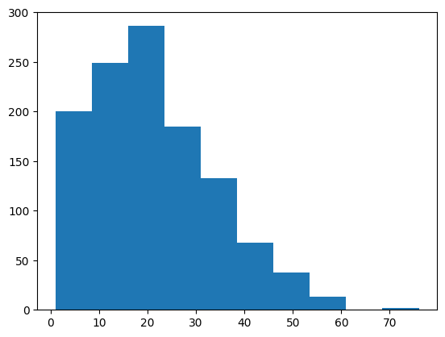

```
[200. 249. 286. 185. 133.  68.  38.  13.   0.   2.]
```

```python
hist = data["International number ID"].value_counts()
n = plt.hist(hist)
plt.show()
print(n[0])
```

- Luckily, more than 75% of typhoons contains >10 rows.

# Make Dataset for ML

- Let's Define our task.
- We're going to predict the typhoon's future state using the typhoon's previous state.
- Than how much previous state datas are we gonna use?
  - Basically, There are 6 hours interval between each row.
  - But in some case, There are 3 hours interval.
  - So using previous state of 3 hours ago is our best option. But there is a lack of data.
  - Let's try to use 6 hours ago data for this time.

## summary

- We're gonna predict typhoon's state of 6 hours later with state of current typhoon and 6 hours previous state of typhoon.
- We'll predict the state of typhoon below.
  - Location(latitude and longitude) of the center, Central Pressure, wind speed, radius of 50kt/30kt winds or greater.

```python
interval = 1
dataset = np.empty((0, 3, 13))
test_typhoons = np.empty((0,3,13))  # Preserve Some typhoons for model evaluation

for typhoon in typhoons:
    nptyphoon = np.array(typhoon)
    for i in range(0, nptyphoon.shape[0]-3, interval):
        single_data = nptyphoon[i:i+3]
        single_data = np.expand_dims(single_data, axis=0)
        if typhoon.iloc[0]["year"]==2022:
            test_typhoons = np.append(test_typhoons, single_data, axis=0)
            continue
        dataset = np.append(dataset, single_data, axis=0)
print(dataset.shape)
print(test_typhoons.shape)
```

```
(20778, 3, 13)
(297, 3, 13)
```

# Machine Learning

```python
# X, Y split
x = dataset[:, :2, :]
y = dataset[:, 2, 5:] # we don't predict year, month, day, hour, and grade

# Train, Test split
from sklearn.model_selection import train_test_split
x_train, x_val, y_train, y_val = train_test_split(x, y, test_size=0.3, random_state=42, shuffle=True)
print(x_train.shape)
print(y_train.shape)
print(x_val.shape)
print(y_val.shape)
```

```
(14544, 2, 13)
(14544, 8)
(6234, 2, 13)
(6234, 8)
```

```python
# Flatten X data
x_train = x_train.reshape(-1, 26)
x_val = x_val.reshape(-1, 26)
```

```python
from sklearn.preprocessing import StandardScaler
scale = StandardScaler()

x_train = scale.fit_transform(x_train)
x_val = scale.transform(x_val)
```

## Linear Regression

```python
from sklearn.linear_model import LinearRegression
from sklearn.metrics import mean_squared_error
lr = LinearRegression()
lr.fit(x_train, y_train)
pred = lr.predict(x_train)
rmse = mean_squared_error(pred, y_train, squared=False)

print("Training Score:", rmse)

pred = lr.predict(x_val)
rmse = mean_squared_error(pred, y_val, squared=False)
print("Test Score:", rmse)
```

```
Training Score: 10.686176285554543
Test Score: 10.784543398309982
```

## Random Forest

```python
from sklearn.ensemble import RandomForestRegressor
rf = RandomForestRegressor(random_state=42)
rf.fit(x_train, y_train)
pred = rf.predict(x_train)
rmse = mean_squared_error(pred, y_train, squared=False)

print("Training Score:", rmse)

pred = rf.predict(x_val)
rmse = mean_squared_error(pred, y_val, squared=False)
print("Test Score:", rmse)
```

```
Training Score: 4.655965608421148
Test Score: 12.517143272553808
```

## Deep Neural Network (MLP)

```python
import torch
from torch import nn
import random

random.seed(42)
torch.manual_seed(42)

x_train_t = torch.tensor(x_train, dtype=torch.float)
x_val_t = torch.tensor(x_val, dtype=torch.float)
y_train_t = torch.tensor(y_train, dtype=torch.float)
y_val_t = torch.tensor(y_val, dtype=torch.float)
```

```python
batch_size=100
training_epochs=15
learning_rate=0.001
```

```python
data_loader = torch.utils.data.DataLoader(dataset=torch.utils.data.TensorDataset(x_train_t, y_train_t),
                          batch_size=batch_size,
                          shuffle=True,
                          drop_last=True)
```

```python
model = nn.Sequential(nn.Linear(x_train_t.shape[1], 10),
                      nn.ReLU(inplace=True),
                      nn.Linear(10, y_train_t.shape[1]))
```

```python
criterion = nn.MSELoss()
optimizer = torch.optim.SGD(model.parameters(), lr=learning_rate)
```

```python
for epoch in range(1, training_epochs+1):
    avg_cost = 0
    total_batch = len(data_loader)

    for x_batch, y_batch in data_loader:
        optimizer.zero_grad()
        hypothesis = model(x_batch)
        cost = criterion(hypothesis, y_batch)
        cost.backward()
        optimizer.step()

        avg_cost += cost
    avg_cost /= total_batch
    if epoch%10 == 0 or True:
        print("Epoch:", epoch, "cost:", avg_cost.item())
```

```
Epoch: 1 cost: 17121.82421875
Epoch: 2 cost: 723.2614135742188
Epoch: 3 cost: 588.4010620117188
Epoch: 4 cost: 510.1949768066406
Epoch: 5 cost: 483.22021484375
Epoch: 6 cost: 453.7836608886719
Epoch: 7 cost: 395.73681640625
Epoch: 8 cost: 349.0601501464844
Epoch: 9 cost: 321.693359375
Epoch: 10 cost: 307.81976318359375
Epoch: 11 cost: 283.3423767089844
Epoch: 12 cost: 270.02862548828125
Epoch: 13 cost: 257.3403015136719
Epoch: 14 cost: 256.2890625
Epoch: 15 cost: 244.77667236328125
```

```python
model.eval()
with torch.no_grad():
    pred = model(x_val_t)

rmse = mean_squared_error(pred, y_val, squared=False)
print("Test Score:", rmse)
```

```
Test Score: 13.557713447297054
```

# Evaluate each model on 2022 typhoon data

```python
x_test = test_typhoons[:, :2, :]
y_test = test_typhoons[:, 2, 5:] # we don't predict year, month, day, hour, and grade
# Flatten X data
x_test = x_test.reshape(-1, 26)
x_test = scale.transform(x_test)
```

```python
lr_pred = lr.predict(x_test)  # Linear Regression
rmse = mean_squared_error(lr_pred, y_test, squared=False)
print("Test Score:", rmse)
```

```
Test Score: 9.529680801952214
```

```python
rf_pred = rf.predict(x_test)  # Random Forest
rmse = mean_squared_error(rf_pred, y_test, squared=False)
print("Test Score:", rmse)
```

```
Test Score: 13.334438212410182
```

```python
x_test_t = torch.tensor(x_test, dtype=torch.float)
with torch.no_grad():
    dl_pred = model(x_test_t)  # MLP

rmse = mean_squared_error(dl_pred, y_test, squared=False)
print("Test Score:", rmse)
```

```
Test Score: 12.080343371213177
```

## Pick a sample

```python
idx = random.randint(0, len(x_test))
x_sample = scale.inverse_transform(x_test[idx].reshape(1, -1))
x_sample = x_sample.reshape(2, -1)
print(x_sample.shape)
print(x_sample.tolist())
```

```
(2, 13)
[[2022.0, 7.0, 29.0, 12.0, 2.0, 30.1, 129.9, 1000.0, 40.0, 0.0, 0.0, 240.0, 150.0], [2022.0, 7.0, 29.0, 18.0, 2.0, 30.7, 128.5, 1000.0, 35.0, 7.105427357601002e-15, -7.105427357601002e-15, 240.0, 150.0]]
```

```python
y_sample = y_test[idx]
lr_pred_sample = np.array(lr_pred[idx])
rf_pred_sample = np.array(rf_pred[idx])
dl_pred_sample = np.array(dl_pred[idx])
# print(y_sample)
# print(pred_sample)
# print(y_sample - pred_sample)
```

```python
import folium
m = folium.Map(location=[x_sample[0][5], x_sample[0][6]], zoom_start=5, width=600, height=600)
folium.Circle(location=[x_sample[0][5], x_sample[0][6]],
             radius=x_sample[0][11]*1852,  #  nautical mile to meter
             fill=True,
             color="black",
             fill_color="yellow")#.add_to(m)
folium.Circle(location=[x_sample[1][5], x_sample[1][6]],
             radius=x_sample[1][11]*1852,  #  nautical mile to meter
             fill=True,
             color="black",
             fill_color="yellow")#.add_to(m)
folium.Circle(location=[y_sample[0], y_sample[1]],
             radius=y_sample[-2]*1852,  #  nautical mile to meter
             fill=True,
             color="purple",
             fill_color="orange").add_to(m)

folium.Circle(location=[lr_pred_sample[0], lr_pred_sample[1]],
             radius=lr_pred_sample[-2]*1852,  #  nautical mile to meter
             fill=True,
             color="blue",
             fill_color="red").add_to(m)
folium.Circle(location=[rf_pred_sample[0], rf_pred_sample[1]],
             radius=rf_pred_sample[-2]*1852,  #  nautical mile to meter
             fill=True,
             color="green",
             fill_color="red").add_to(m)
folium.Circle(location=[dl_pred_sample[0], dl_pred_sample[1]],
             radius=dl_pred_sample[-2]*1852,  #  nautical mile to meter
             fill=True,
             color="black",
             fill_color="red").add_to(m)
m
```

[output not shown]

[output cut: 88 more lines]

[output not shown]

```
<folium.folium.Map at 0x1429d9b2c60>
```